# Data Analysis Lecture

BEE - HT 2024

Francis J. DiTraglia

University of Oxford

## R Resources

### Basics

- This very lecture you are currently attending!
- Llaudet & Imai (2022) - Data Analysis for Social Science: A Friendly and Practical Introduction
- [Econ 103 - My old intro statistics course from UPenn](https://ditraglia.com/Econ103Public)

### More Advanced / Cooler

- [Wickham & Grolemund (2023) - R for Data Science](https://r4ds.hadley.nz/)
- [Core ERM](https://ditraglia.com/erm/)

## How did I make these slides?

- I most definitely *did not* copy-and-paste R code, results and figures into Powerpoint!
- I used [Quarto](https://quarto.org/). I could just as easily have used [R Markdown](https://rmarkdown.rstudio.com/).
- The first few slides of this [slide deck](https://ditraglia.com/erm/05-plumbing.html) give an overview.
- [Chapter 29](https://r4ds.hadley.nz/communicate) of R for Data Science explains Quarto.
- It’s totally optional, but you can use these tools to generate your BEE reports if you like.

# Analyzing Data from a Simple RCT

## The Anchoring Experiment

- Classic experiment from Kahneman & Tversky; data from my undergraduate class at UPenn
- Question: does irrelevant information change behavior?
- Students randomly allocated to “Lo” and “Hi” groups.
  - “Lo” group shown the number 10
  - “Hi” group shown the number 65
- Asked a pair of questions about African countries in the UN.

## Experimental Instructions

> We chose (by computer) a random number between 0 and 100. The number selected and assigned to you is written on a slip of paper in front of you. Please do not show your number to anyone else or look at anyone else’s number.

> Call your random number X. Do you think that the *percentage* of countries, among all those in the United Nations, that are in Africa is *higher* or *lower* than X?

> What is your best estimate of the *percentage* of countries, among all those that are in the United Nations, that are in Africa?

## Read in the data

- `read.csv()` to read the file `old_survey.csv` from my website and store it as an R dataframe called `anchoring`.
- `names()` to list the names of all the columns in `anchoring`
- `head()` to display the first few rows of the dataframe.
- Each row is a student:
  - `rand.num`: experimental treatment (10 or 65)
  - `africa.higher`: answer to first question (“*higher* or *lower* than X?”)
  - `africa.percent`: answer to second question (“*percentage* of countries” )
  - remaining columns: survey responses, some missing (`NA`)

## Read in the data

```r
anchoring <- read.csv('https://ditraglia.com/data/old_survey.csv')
names(anchoring)
```

```
 [1] "sex"            "credits"        "eye.color"      "handedness"
 [5] "height"         "handspan"       "bias"           "rand.num"
 [9] "africa.higher"  "africa.percent"
```

```r
head(anchoring)
```

```
     sex credits eye.color handedness height handspan bias rand.num
1   Male       5     Brown        1.0     67     20.0   No       10
2 Female       5     Brown        0.4     63     19.5  Yes       65
3 Female      NA     Brown        0.6     62     19.0   No       65
4 Female       5     Brown        0.6     65     19.5   No       65
5 Female       4     Brown        1.0     62     18.5  Yes       65
6 Female      NA     Brown        1.0     68     18.5  Yes       65
  africa.higher africa.percent
1        Higher             20
2         Lower             25
3         Lower             43
4         Lower             20
5         Lower             26
6         Lower             60
```

## Access a Column with `$`

```r
anchoring$rand.num
```

```
 [1] 10 65 65 65 65 65 65 10 65 65 65 10 65 10 10 65 10 65 10 10 65 10 10 65 10
[26] 10 10 10 65 65 10 65 10 10 65 65 65 65 65 10 65 65 10 65 10 10 65 10 10 65
[51] 65 10 10 65 65 65 10 65 65 10 65 65 10 65 10 10 10 65 65 10 65 10 10 10 65
[76] 10 65 65 10 65 65 10 10 10 10 65 65 10 10
```

## Boxplot for `height`

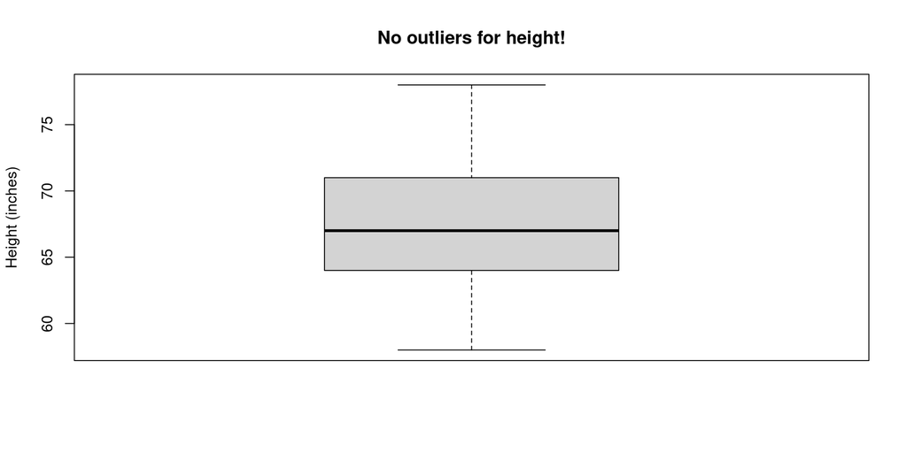

```r
boxplot(anchoring$height,
        main = 'No outliers for height!',
        ylab = 'Height (inches)')
```

## Boxplot for `handspan`

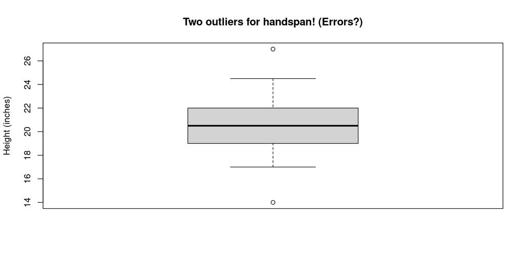

```r
boxplot(anchoring$handspan,
        main = 'Two outliers for handspan! (Errors?)',
        ylab = 'Height (inches)')
```

## Boxplots by Group

- Compare two boxplots: “Lo” versus “Hi” groups
- Formula syntax: `OUTCOME_VARIABLE_HERE ~ GROUPING_VARIABLE_HERE`
- What do we conclude?

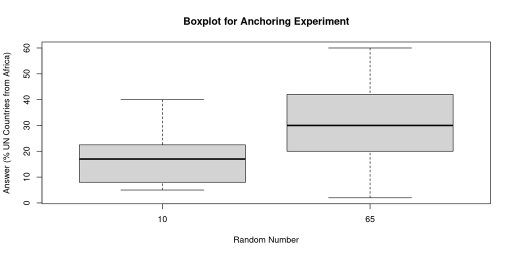

```r
boxplot(anchoring$africa.percent ~ anchoring$rand.num,
        main = 'Boxplot for Anchoring Experiment',
        ylab = 'Answer (% UN Countries from Africa)',
        xlab = 'Random Number')
```

## Summary Statistics

- `mean()` to compute the sample mean of a vector
- `median()` to compute the sample median
- `sd()` to compute the sample standard deviation
- `var()` to compute the sample variance
- `IQR()` to compute the interquartile range

## Missing Values

- `NA` means “I don’t know”
- Some students only compelted part of the survey: their heights are `NA` (missing)
- The mean of a vector with missing values is `NA`
- Setting `na.rm = TRUE` drops missing values before computing the mean

```r
mean(anchoring$height)
```

```
[1] NA
```

```r
var(anchoring$height)
```

```
[1] NA
```

```r
mean(anchoring$height, na.rm = TRUE)
```

```
[1] 67.54545
```

```r
var(anchoring$height, na.rm = TRUE)
```

```
[1] 19.74504
```

## Testing for Equality

The double equals `==` operator returns `TRUE` if both sides are equal to each other, `FALSE` otherwise

```r
0.5 == 1/2
```

```
[1] TRUE
```

```r
'cat' == 'dog'
```

```
[1] FALSE
```

## Select Elements with `TRUE`/`FALSE`

- Use `c()` to create a vector of elements
- Use brackets `[]` to select elements of a vector

```r
x <- c('BEE', 'is', 'the', 'best')
some_words <- c(TRUE, FALSE, FALSE, TRUE)
x[some_words]
```

```
[1] "BEE"  "best"
```

## Comparing Means Across Groups

Calculate the difference of mean answers: “Hi” minus “Lo”

```r
Hi <- anchoring$rand.num == 65 # TRUE if Hi group, FALSE otherwise
mean_Hi <- mean(anchoring$africa.percent[Hi])

Lo <- anchoring$rand.num == 10 # TRUE if Lo group, FALSE otherwise
mean_Lo <- mean(anchoring$africa.percent[Lo])

mean_Hi - mean_Lo
```

```
[1] 13.62437
```

## A Two-sample t-Test

- `t.test()` to build a confidence interval or carry out a t-test
- For a two-sample test provide two vectors `x` and `y` with data for the two groups.
- Defaults to 95% CI and *does not assume* equal variances across groups
- For more information: `?t.test()`
- What do we conclude?

```r
t.test(x = anchoring$africa.percent[Hi],
       y = anchoring$africa.percent[Lo])
```

```
    Welch Two Sample t-test

data:  anchoring$africa.percent[Hi] and anchoring$africa.percent[Lo]
t = 4.9704, df = 73.27, p-value = 4.252e-06
alternative hypothesis: true difference in means is not equal to 0
95 percent confidence interval:
  8.161655 19.087081
sample estimates:
mean of x mean of y
 30.71739  17.09302
```

# Testing a Theoretical Model

## The Common Value Auction<sup>1</sup>

- Two players, each shown private signal: $V_i \sim \text{Unif}(0, L)$.
- Each bids for a cash prize with value $\bar{V} \equiv (V_1 + V_2)/2$.
- Highest bidder wins; receives $\bar{V}$ minus their bid
- Nash Equilibrium bid function (risk neutral): $V_i / 2$.
- Are experimental participants subject to a “winners curse?” In other words, do they systematically overbid?
[^1]: [Holt & Sherman (2014)](https://www.jstor.org/stable/23809662)

## Loading Data from Excel

- Sometimes you have to read data from excel (SHUDDER)
- Rather than converting to `.csv` in Excel, load the raw `.xls` or `.xlsx` file into R with the `readxl` package.
- Install (first time only): `install.packages('readxl')`
- Load (every time): `library(readxl)`

## Download the Data

- https://ditraglia.com/data/common-value-auction.xlsx
- Save it somewhere where you will be able to find it.
- Find the file path of the directory where you saved the file

```r
library(readxl)
setwd('~/Dropbox/oxford-tutorials/BEE-MT-2023/data-analysis-lecture/')
common_value <- read_excel('common-value-auction.xlsx')
```

## Experimental Data

- `Session`: experimental session (1-8)
- `Month`: calendar month (D for December, J for January)
- `Range`: the value of $L$ for the $\text{Uniform}(0,L)$ signals (5 or 10)
- `ID_self`: participant ID (unique within a given session)
- `ID_partner`: ID of partner for the common value auction
- `Signal`: the $\text{Uniform}(0,L)$ private signal
- `Bid`: the player’s bid

```r
head(common_value)
```

```
# A tibble: 6 × 8
  Session Month Range Round ID_self ID_partner Signal   Bid
    <dbl> <chr> <dbl> <dbl>   <dbl>      <dbl>  <dbl> <dbl>
1       1 D        10     1       1         10   8.97  4
2       1 D        10     1       2          3   6.27  3
3       1 D        10     1       3          2   2.06  2
4       1 D        10     1       4          7   0.39  0.6
5       1 D        10     1       5          9   3.15  1.02
6       1 D        10     1       6          8   0.58  1
```

## Note

- Each student participated in multiple experimental rounds
- Random (re-)matching of partners each round
- I keep only round 1 data to exclude “learning” or “feedback”

## Plotting a Histogram with `hist()`

- Make histograms for sessions with $L = 10$ and $L = 5$
- Notice anything strange?

```r
L5 <- common_value$Range == 5
L10 <- common_value$Range == 10
par(mfrow = c(1, 2)) # put the plots side-by-side
hist(common_value$Signal[L5], xlab = 'Signal', main = 'L = 5')
hist(common_value$Signal[L10], xlab = 'Signal', main = 'L = 10')
```

```r
par(mfrow = c(1, 1)) # go back to the default plotting layout
```

[figure not shown]

## Selecting and Rows from a Dataframe

Something weird is going on here. Let’s take a closer look:

```r
weird <- (common_value$Range == 5) & (common_value$Signal > 5)
common_value[weird, ]
```

```
# A tibble: 5 × 8
  Session Month Range Round ID_self ID_partner Signal   Bid
    <dbl> <chr> <dbl> <dbl>   <dbl>      <dbl>  <dbl> <dbl>
1       7 J         5     1       1         10   5.48  5.02
2       7 J         5     1       2          7   5.24  3
3       7 J         5     1       3          8   8.53  4.5
4       7 J         5     1       4          9   7.94  8
5       7 J         5     1      10          3   9.05  4.5
```

## Dropping Rows from a Dataframe

- Something is wrong with a few signals from session 7.
- To be on the safe side, I will drop that whole session.
- (You would need to explain this in your report!)

```r
session7 <- common_value$Session == 7
common_value_cleaned <- common_value[!session7,]
```

## Making a Scatterplot

- `plot(y ~ x)` makes a scatterplot of `y` against `x`
- Plot bids against signals; each point is an experimental participant
- `abline(a = INTERCEPT, b = SLOPE)` *adds* a line to an existing plot
- Overlay the line $\text{Bid} = \text{Signal} / 2$. What do we observe?

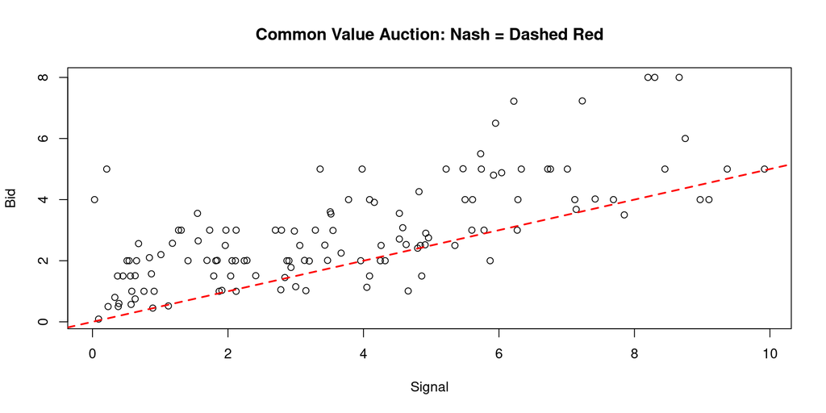

```r
plot(Bid ~ Signal, data = common_value_cleaned,
     main = 'Common Value Auction: Nash = Dashed Red')
abline(a = 0, b = 0.5, lwd = 2, lty = 2, col = 'red')
```

## Running a Regression

- `lm(y ~ x, data = [DATAFRAME_HERE])` runs the regression
- `summary([REGRESSION_HERE])` displays the results

```r
regression_results <- lm(Bid ~ Signal, data = common_value_cleaned)
summary(regression_results)
```

```
Call:
lm(formula = Bid ~ Signal, data = common_value_cleaned)

Residuals:
    Min      1Q  Median      3Q     Max
-2.3743 -0.8351 -0.1894  0.6853  3.7839

Coefficients:
            Estimate Std. Error t value Pr(>|t|)
(Intercept)  1.11375    0.18797   5.925 2.87e-08 ***
Signal       0.48724    0.04224  11.534  < 2e-16 ***
---
Signif. codes:  0 '***' 0.001 '**' 0.01 '*' 0.05 '.' 0.1 ' ' 1

Residual standard error: 1.184 on 124 degrees of freedom
Multiple R-squared:  0.5176,    Adjusted R-squared:  0.5137
F-statistic:   133 on 1 and 124 DF,  p-value: < 2.2e-16
```

## Regression Line vs Nash Equilibrium

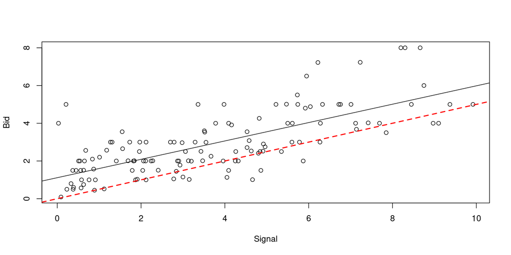

```r
plot(Bid ~ Signal, data = common_value_cleaned)
abline(a = 1.114, b = 0.487)
abline(a = 0, b = 0.5, lwd = 2, lty = 2, col = 'red')
```

## If you insist: F-test of Nash Prediction

- I prefer to look at estimates and standard errors…
- Confused? Try [this blog post](https://www.econometrics.blog/post/understanding-the-f-statistic/)

```r
library(car)
linearHypothesis(regression_results,
                 c('Signal = 0.5', '(Intercept) = 0'))
```

```
Linear hypothesis test

Hypothesis:
Signal = 0.5
(Intercept) = 0

Model 1: restricted model
Model 2: Bid ~ Signal

  Res.Df    RSS Df Sum of Sq      F    Pr(>F)
1    126 317.21
2    124 173.71  2    143.51 51.222 < 2.2e-16 ***
---
Signif. codes:  0 '***' 0.001 '**' 0.01 '*' 0.05 '.' 0.1 ' ' 1
```